# Reproducible Research: Peer Assessment 1

## Loading and preprocessing the data

Data comes from cloned repo:

```
git clone https://github.com/rdpeng/RepData_PeerAssessment1.git
```

Reading data into R and aggregate the values into StepsByData:

```r
MyActivityData <- read.csv('activity.csv')
StepsByDay <- aggregate(steps ~ date, MyActivityData, sum)
```

## What is mean total number of steps taken per day?

Make a histogram of the total number of steps taken each day

[figure not shown]

```r
hist(StepsByDay$steps, main = paste("Total Steps / Day"), col="grey", xlab="No Steps")
```

Calculate and report the mean and median total number of steps taken per day

```r
MyMean <- mean(StepsByDay$steps)
show(MyMean)
[1] 10766.19
```

- The mean is 10766.19.

```r
MyMedian <- median(StepsByDay$steps)
show(MyMedian)
[1] 10765
```

- The median is 10765.

## What is the average daily activity pattern?

Make a time series plot (i.e. type = “l”) of the 5-minute interval (x-axis) and the average number of steps taken, averaged across all days (y-axis)

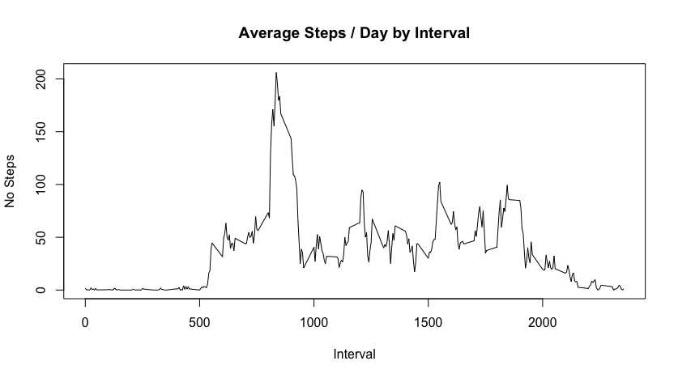

```r
StepsByInterval <- aggregate(steps ~ interval, MyActivityData, mean)
plot(StepsByInterval$interval,StepsByInterval$steps, type="l", xlab="Interval", ylab="No Steps",main="Average Steps / Day by Interval")
```

Which 5-minute interval, on average across all the days in the dataset, contains the maximum number of steps?

```r
MyMaxInterval <- StepsByInterval[which.max(StepsByInterval$steps),1]
show(MyMaxInterval)
[1] 835

TimeMaxSteps <-  gsub("([0-9]{1,2})([0-9]{2})", "\\1:\\2", StepsByInterval[MyMaxInterval,'interval'])
```

- The Maximum is at Interval 835.

## Imputing missing values

Calculate and report the total number of missing values in the dataset (i.e. the total number of rows with NAs)

```r
MyNASum <- sum(is.na(MyActivityData$steps))
> show(MyNASum)
[1] 2304
```

- The total of N/A is 2304.

Devise a strategy for filling in all of the missing values in the dataset. The strategy does not need to be sophisticated. For example, you could use the mean/median for that day, or the mean for that 5-minute interval, etc.

-> I choose to use the 5min interval values for filling N/A gaps.

```r
MyImputedActivity <- merge(MyActivityData,
                          StepsByInterval,
                          by="interval",
                          suffixes=c("",".interval.mean"))

MyNAData <- is.na(MyImputedActivity$steps)
MyImputedActivity$steps[MyNAData] <- MyImputedActivity$steps.interval.mean[MyNAData]
MyImputedActivity <- MyImputedActivity[,1:3]
```

Make a histogram of the total number of steps taken each day and Calculate and report the mean and median total number of steps taken per day.

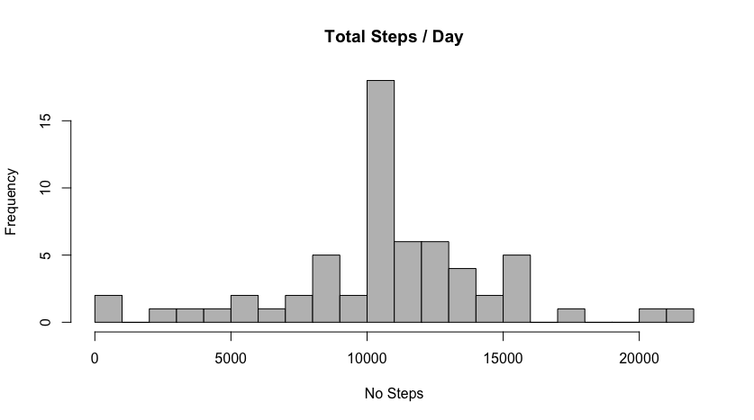

```r
hist(MyImputedStepsByDay$steps, main = paste("Total Steps / Day"), col="grey", xlab="No Steps", breaks=30)
```

Calculate new mean and median for imputed data.

```r
MyImputedMean <- mean(MyImputedStepsByDay$steps)
> show(MyImputedMean)
[1] 10766.19
```

```r
MyImputedMedian <- median(MyImputedStepsByDay$steps)
> show(MyImputedMedian)
[1] 10766.19
```

## Are there differences in activity patterns between weekdays and weekends?

Create a new factor variable in the dataset with two levels – “weekday” and “weekend” indicating whether a given date is a weekday or weekend day.

```r
myweekday <- function(date) {
    if (weekdays(as.Date(date)) %in% c("Samstag", "Sonntag")) {
        "weekendday"
    } else {
        "weekday"
    }
}

MyImputedActivityData$myweekday <- as.factor(sapply(MyImputedActivityData$date, myweekday))
```

**Remark:** Took me quite some time to find out that I had non-english locale on my computer and that I had to use the Swiss/German weekday names.

Make a panel plot containing a time series plot (i.e. type = “l”) of the 5-minute interval (x-axis) and the average number of steps taken, averaged across all weekday days or weekend days (y-axis).

[figure not shown]

```r
xyplot(myImputedStepsByIntervalWeekdays$steps ~ myImputedStepsByIntervalWeekdays$interval|myImputedStepsByIntervalWeekdays$myweekday, main="Average Steps/Day per Interval",xlab="Interval", ylab="Steps",layout=c(1,2), type="l")
```